# Lab 9: SVM and PCA

**Aim:** Implement SVM for classification and PCA for dimensionality reduction using real-world datasets.

**Objectives**

- Train and tune a linear-kernel SVM.
- Evaluate it using standard classification metrics.
- Reduce high-dimensional data using PCA and study retained variance.
- Compare PCA with supervised LDA.

```python
import warnings
warnings.filterwarnings("ignore")

import numpy as np
import pandas as pd
import matplotlib.pyplot as plt
import seaborn as sns

from sklearn.datasets import load_breast_cancer, load_wine
from sklearn.discriminant_analysis import LinearDiscriminantAnalysis
from sklearn.decomposition import PCA
from sklearn.metrics import (
    accuracy_score, precision_score, recall_score, f1_score,
    confusion_matrix, classification_report, silhouette_score
)
from sklearn.model_selection import GridSearchCV, cross_val_score, train_test_split
from sklearn.pipeline import Pipeline
from sklearn.preprocessing import StandardScaler
from sklearn.svm import SVC

RANDOM_STATE = 42
sns.set_theme(style="whitegrid", context="notebook")
pd.set_option("display.max_columns", 15)
```

## Part A: Support Vector Machine (SVM)

Dataset: [UCI Breast Cancer Wisconsin (Diagnostic)](https://archive.ics.uci.edu/dataset/17/breast+cancer+wisconsin+diagnostic). The scikit-learn copy is used so the notebook runs without a network connection.

```python
cancer = load_breast_cancer(as_frame=True)
X_cancer = cancer.data
y_cancer = cancer.target

cancer_summary = pd.DataFrame({
    "Value": [X_cancer.shape[0], X_cancer.shape[1], int(X_cancer.isna().sum().sum()), cancer.target_names.tolist()]
}, index=["Samples", "Features", "Missing values", "Classes (encoded 0, 1)"])
display(cancer_summary)
display(X_cancer.head())
print("Class counts:")
display(y_cancer.map(dict(enumerate(cancer.target_names))).value_counts().to_frame("count"))
```

|  | Value |
| --- | --- |
| Samples | 569 |
| Features | 30 |
| Missing values | 0 |
| Classes (encoded 0, 1) | [malignant, benign] |

|  | mean radius | mean texture | mean perimeter | mean area | mean smoothness | mean compactness | mean concavity | ... | worst area | worst smoothness | worst compactness | worst concavity | worst concave points | worst symmetry | worst fractal dimension |
| --- | --- | --- | --- | --- | --- | --- | --- | --- | --- | --- | --- | --- | --- | --- | --- |
| 0 | 17.99 | 10.38 | 122.80 | 1001.0 | 0.11840 | 0.27760 | 0.3001 | ... | 2019.0 | 0.1622 | 0.6656 | 0.7119 | 0.2654 | 0.4601 | 0.11890 |
| 1 | 20.57 | 17.77 | 132.90 | 1326.0 | 0.08474 | 0.07864 | 0.0869 | ... | 1956.0 | 0.1238 | 0.1866 | 0.2416 | 0.1860 | 0.2750 | 0.08902 |
| 2 | 19.69 | 21.25 | 130.00 | 1203.0 | 0.10960 | 0.15990 | 0.1974 | ... | 1709.0 | 0.1444 | 0.4245 | 0.4504 | 0.2430 | 0.3613 | 0.08758 |
| 3 | 11.42 | 20.38 | 77.58 | 386.1 | 0.14250 | 0.28390 | 0.2414 | ... | 567.7 | 0.2098 | 0.8663 | 0.6869 | 0.2575 | 0.6638 | 0.17300 |
| 4 | 20.29 | 14.34 | 135.10 | 1297.0 | 0.10030 | 0.13280 | 0.1980 | ... | 1575.0 | 0.1374 | 0.2050 | 0.4000 | 0.1625 | 0.2364 | 0.07678 |

5 rows × 30 columns

```
Class counts:
```

| target | count |
| --- | --- |
| benign | 357 |
| malignant | 212 |

### Preprocessing and 80:20 split

- The dataset has no missing values.
- Stratification keeps the class ratio similar in both sets.
- Standardization is fitted only on training folds through a pipeline.

```python
X_train, X_test, y_train, y_test = train_test_split(
    X_cancer, y_cancer, test_size=0.20, stratify=y_cancer, random_state=RANDOM_STATE
)
print(f"Training samples: {len(X_train)} | Testing samples: {len(X_test)}")

# Brief kernel comparison on training data only. The required final model remains linear.
kernel_results = []
for kernel in ["linear", "rbf", "poly", "sigmoid"]:
    candidate = Pipeline([
        ("scaler", StandardScaler()),
        ("svm", SVC(kernel=kernel, C=1)),
    ])
    scores = cross_val_score(candidate, X_train, y_train, cv=5, scoring="f1_macro")
    kernel_results.append({"Kernel": kernel, "Mean CV Macro F1": scores.mean(), "CV Std. Dev.": scores.std()})
kernel_comparison = pd.DataFrame(kernel_results).sort_values("Mean CV Macro F1", ascending=False)
display(kernel_comparison.style.format({"Mean CV Macro F1": "{:.4f}", "CV Std. Dev.": "{:.4f}"}))

svm_pipeline = Pipeline([
    ("scaler", StandardScaler()),
    ("svm", SVC(kernel="linear"))
])

param_grid = {
    "svm__C": [0.01, 0.1, 1, 10, 100],
    "svm__class_weight": [None, "balanced"],
}
grid_search = GridSearchCV(
    svm_pipeline, param_grid, cv=5, scoring="f1_macro", n_jobs=-1, return_train_score=True
)
grid_search.fit(X_train, y_train)

cv_results = pd.DataFrame(grid_search.cv_results_)[
    ["param_svm__C", "param_svm__class_weight", "mean_train_score", "mean_test_score", "rank_test_score"]
].sort_values("rank_test_score")
display(cv_results.head(10).style.format({"mean_train_score": "{:.4f}", "mean_test_score": "{:.4f}"}))
print("Best parameters:", grid_search.best_params_)
print(f"Best mean cross-validation macro F1: {grid_search.best_score_:.4f}")
```

```
Training samples: 455 | Testing samples: 114
```

|  | Kernel | Mean CV Macro F1 | CV Std. Dev. |
| --- | --- | --- | --- |
| 1 | rbf | 0.9694 | 0.0193 |
| 0 | linear | 0.9646 | 0.0150 |
| 3 | sigmoid | 0.9641 | 0.0110 |
| 2 | poly | 0.8813 | 0.0223 |

|  | param_svm__C | param_svm__class_weight | mean_train_score | mean_test_score | rank_test_score |
| --- | --- | --- | --- | --- | --- |
| 3 | 0.100000 | balanced | 0.9853 | 0.9764 | 1 |
| 2 | 0.100000 | nan | 0.9841 | 0.9762 | 2 |
| 1 | 0.010000 | balanced | 0.9817 | 0.9741 | 3 |
| 0 | 0.010000 | nan | 0.9756 | 0.9712 | 4 |
| 5 | 1.000000 | balanced | 0.9883 | 0.9670 | 5 |
| 4 | 1.000000 | nan | 0.9894 | 0.9646 | 6 |
| 6 | 10.000000 | nan | 0.9941 | 0.9625 | 7 |
| 7 | 10.000000 | balanced | 0.9936 | 0.9625 | 8 |
| 8 | 100.000000 | nan | 0.9988 | 0.9417 | 9 |
| 9 | 100.000000 | balanced | 0.9982 | 0.9417 | 9 |

```
Best parameters: {'svm__C': 0.1, 'svm__class_weight': 'balanced'}
Best mean cross-validation macro F1: 0.9764
```

|  | Score |
| --- | --- |
| Accuracy | 0.9649 |
| Precision (malignant) | 0.9318 |
| Recall (malignant) | 0.9762 |
| F1 Score (malignant) | 0.9535 |

```
Classification report:
              precision    recall  f1-score   support

   malignant     0.9318    0.9762    0.9535        42
      benign     0.9857    0.9583    0.9718        72

    accuracy                         0.9649       114
   macro avg     0.9588    0.9673    0.9627       114
weighted avg     0.9659    0.9649    0.9651       114
```

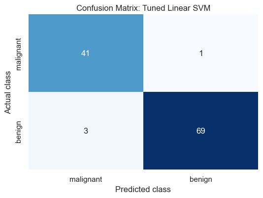

```python
best_svm = grid_search.best_estimator_
y_pred = best_svm.predict(X_test)

# Malignant (label 0) is treated as the positive class because detecting it is important.
svm_metrics = pd.DataFrame({
    "Score": [
        accuracy_score(y_test, y_pred),
        precision_score(y_test, y_pred, pos_label=0),
        recall_score(y_test, y_pred, pos_label=0),
        f1_score(y_test, y_pred, pos_label=0),
    ]
}, index=["Accuracy", "Precision (malignant)", "Recall (malignant)", "F1 Score (malignant)"])
display(svm_metrics.style.format("{:.4f}"))

print("Classification report:")
print(classification_report(y_test, y_pred, target_names=cancer.target_names, digits=4))

cm = confusion_matrix(y_test, y_pred, labels=[0, 1])
plt.figure(figsize=(5.5, 4.2))
sns.heatmap(cm, annot=True, fmt="d", cmap="Blues", cbar=False,
            xticklabels=cancer.target_names, yticklabels=cancer.target_names)
plt.title("Confusion Matrix: Tuned Linear SVM")
plt.xlabel("Predicted class")
plt.ylabel("Actual class")
plt.tight_layout()
plt.show()
```

```python
tn_m, fp_m, fn_m, tp_m = cm.ravel()  # Matrix order is [malignant, benign].
print("SVM observations:")
print(f"- Standardization helps SVM handle features with different scales.")
print(f"- At C=1, {kernel_comparison.iloc[0]['Kernel']} had the highest cross-validation macro F1 among the tested kernels.")
print(f"- Tuning selected C={grid_search.best_params_['svm__C']} and class_weight={grid_search.best_params_['svm__class_weight']}.")
print(f"- Test accuracy is {svm_metrics.loc['Accuracy', 'Score']:.2%}.")
print(f"- The model correctly detected {cm[0, 0]} of {cm[0].sum()} malignant cases.")
print(f"- The linear boundary performs well, so the standardized classes are close to linearly separable.")
```

```
SVM observations:
- Standardization helps SVM handle features with different scales.
- At C=1, rbf had the highest cross-validation macro F1 among the tested kernels.
- Tuning selected C=0.1 and class_weight=balanced.
- Test accuracy is 96.49%.
- The model correctly detected 41 of 42 malignant cases.
- The linear boundary performs well, so the standardized classes are close to linearly separable.
```

## Part B: Principal Component Analysis (PCA)

Dataset: [UCI Wine](https://archive.ics.uci.edu/dataset/109/wine). The scikit-learn copy contains the same 13 numeric chemical features and three wine classes.

```python
wine = load_wine(as_frame=True)
X_wine = wine.data
y_wine = wine.target

wine_summary = pd.DataFrame({
    "Value": [X_wine.shape[0], X_wine.shape[1], int(X_wine.isna().sum().sum()), len(wine.target_names)]
}, index=["Samples", "Original features", "Missing values", "Classes"])
display(wine_summary)
display(X_wine.head())

wine_scaler = StandardScaler()
X_wine_scaled = wine_scaler.fit_transform(X_wine)
print("Mean after scaling (approximately 0):", np.abs(X_wine_scaled.mean(axis=0)).max().round(10))
print("Standard deviation after scaling (approximately 1):", X_wine_scaled.std(axis=0).mean().round(10))
```

|  | Value |
| --- | --- |
| Samples | 178 |
| Original features | 13 |
| Missing values | 0 |
| Classes | 3 |

|  | alcohol | malic_acid | ash | alcalinity_of_ash | magnesium | total_phenols | flavanoids | nonflavanoid_phenols | proanthocyanins | color_intensity | hue | od280/od315_of_diluted_wines | proline |
| --- | --- | --- | --- | --- | --- | --- | --- | --- | --- | --- | --- | --- | --- |
| 0 | 14.23 | 1.71 | 2.43 | 15.6 | 127.0 | 2.80 | 3.06 | 0.28 | 2.29 | 5.64 | 1.04 | 3.92 | 1065.0 |
| 1 | 13.20 | 1.78 | 2.14 | 11.2 | 100.0 | 2.65 | 2.76 | 0.26 | 1.28 | 4.38 | 1.05 | 3.40 | 1050.0 |
| 2 | 13.16 | 2.36 | 2.67 | 18.6 | 101.0 | 2.80 | 3.24 | 0.30 | 2.81 | 5.68 | 1.03 | 3.17 | 1185.0 |
| 3 | 14.37 | 1.95 | 2.50 | 16.8 | 113.0 | 3.85 | 3.49 | 0.24 | 2.18 | 7.80 | 0.86 | 3.45 | 1480.0 |
| 4 | 13.24 | 2.59 | 2.87 | 21.0 | 118.0 | 2.80 | 2.69 | 0.39 | 1.82 | 4.32 | 1.04 | 2.93 | 735.0 |

```
Mean after scaling (approximately 0): 0.0
Standard deviation after scaling (approximately 1): 1.0
```

### Explained variance and the 95% threshold

|  | Principal Component | Explained Variance Ratio | Cumulative Variance |
| --- | --- | --- | --- |
| 0 | PC1 | 0.3620 | 0.3620 |
| 1 | PC2 | 0.1921 | 0.5541 |
| 2 | PC3 | 0.1112 | 0.6653 |
| 3 | PC4 | 0.0707 | 0.7360 |
| 4 | PC5 | 0.0656 | 0.8016 |
| 5 | PC6 | 0.0494 | 0.8510 |
| 6 | PC7 | 0.0424 | 0.8934 |
| 7 | PC8 | 0.0268 | 0.9202 |
| 8 | PC9 | 0.0222 | 0.9424 |
| 9 | PC10 | 0.0193 | 0.9617 |
| 10 | PC11 | 0.0174 | 0.9791 |
| 11 | PC12 | 0.0130 | 0.9920 |
| 12 | PC13 | 0.0080 | 1.0000 |

```
Minimum components needed to retain at least 95% variance: 10
```

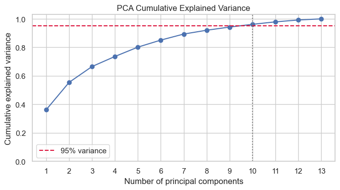

```python
pca_all = PCA().fit(X_wine_scaled)
explained = pca_all.explained_variance_ratio_
cumulative = np.cumsum(explained)
min_components_95 = int(np.argmax(cumulative >= 0.95) + 1)

variance_table = pd.DataFrame({
    "Principal Component": [f"PC{i}" for i in range(1, len(explained) + 1)],
    "Explained Variance Ratio": explained,
    "Cumulative Variance": cumulative,
})
display(variance_table.style.format({
    "Explained Variance Ratio": "{:.4f}", "Cumulative Variance": "{:.4f}"
}))
print(f"Minimum components needed to retain at least 95% variance: {min_components_95}")

plt.figure(figsize=(7, 4))
plt.plot(range(1, len(cumulative) + 1), cumulative, marker="o")
plt.axhline(0.95, color="crimson", linestyle="--", label="95% variance")
plt.axvline(min_components_95, color="gray", linestyle=":")
plt.xticks(range(1, len(cumulative) + 1))
plt.ylim(0, 1.03)
plt.xlabel("Number of principal components")
plt.ylabel("Cumulative explained variance")
plt.title("PCA Cumulative Explained Variance")
plt.legend()
plt.tight_layout()
plt.show()
```

```
Explained variance ratio of PC1 and PC2: [0.362  0.1921]
Total variance retained in 2D: 55.41%
```

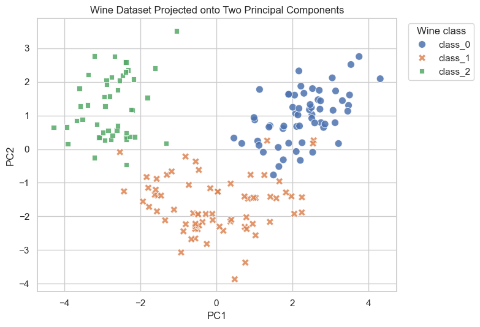

```python
pca_2 = PCA(n_components=2)
X_pca = pca_2.fit_transform(X_wine_scaled)
pca_df = pd.DataFrame(X_pca, columns=["PC1", "PC2"])
pca_df["Class"] = y_wine.map(dict(enumerate(wine.target_names)))

print("Explained variance ratio of PC1 and PC2:", np.round(pca_2.explained_variance_ratio_, 4))
print(f"Total variance retained in 2D: {pca_2.explained_variance_ratio_.sum():.2%}")

plt.figure(figsize=(8, 5.5))
sns.scatterplot(data=pca_df, x="PC1", y="PC2", hue="Class", style="Class", s=75, alpha=0.85)
plt.title("Wine Dataset Projected onto Two Principal Components")
plt.legend(title="Wine class", bbox_to_anchor=(1.02, 1), loc="upper left")
plt.tight_layout()
plt.show()
```

```python
loadings = pd.DataFrame(
    pca_2.components_.T, index=X_wine.columns, columns=["PC1", "PC2"]
)
for component in loadings.columns:
    print(f"Largest absolute loadings for {component}:")
    display(loadings[component].reindex(loadings[component].abs().sort_values(ascending=False).index).head(5).to_frame())

dataset_comparison = pd.DataFrame({
    "Original standardized data": [13, "100%", "Higher"],
    "PCA transformed data": [2, f"{pca_2.explained_variance_ratio_.sum():.2%}", "Lower"],
}, index=["Number of features", "Information retained", "Later computation cost"])
display(dataset_comparison)
```

```
Largest absolute loadings for PC1:
```

|  | PC1 |
| --- | --- |
| flavanoids | 0.422934 |
| total_phenols | 0.394661 |
| od280/od315_of_diluted_wines | 0.376167 |
| proanthocyanins | 0.313429 |
| nonflavanoid_phenols | -0.298533 |

```
Largest absolute loadings for PC2:
```

|  | PC2 |
| --- | --- |
| color_intensity | 0.529996 |
| alcohol | 0.483652 |
| proline | 0.364903 |
| ash | 0.316069 |
| magnesium | 0.299634 |

|  | Original standardized data | PCA transformed data |
| --- | --- | --- |
| Number of features | 13 | 2 |
| Information retained | 100% | 55.41% |
| Later computation cost | Higher | Lower |

### PCA interpretation

- **PC1** captures the largest overall variation and is strongly influenced by phenol- and flavonoid-related measurements.
- **PC2** captures the next independent direction and is strongly influenced by alcohol and color-related measurements.
- Nearby points have similar standardized chemical profiles.
- Sign flips do not change a component's meaning; loading magnitude shows importance.

### Advantages, limitations, and applications

**Advantages**

- Reduces feature count, noise, storage, and later computation.
- Removes multicollinearity because components are uncorrelated.
- Makes high-dimensional data easier to visualize.

**Limitations**

- Components are less interpretable than original features.
- PCA is linear and can miss nonlinear structure.
- It ignores class labels and is sensitive to feature scaling and outliers.

**Applications**

- Visualization, compression, noise reduction, preprocessing, and feature extraction.

## Extra Credit: Linear Discriminant Analysis (LDA)

LDA uses the known class labels and searches for directions that separate the classes. With three classes, it can produce at most two discriminants.

```
LDA explained discriminative variance ratio: [0.6875 0.3125]
```

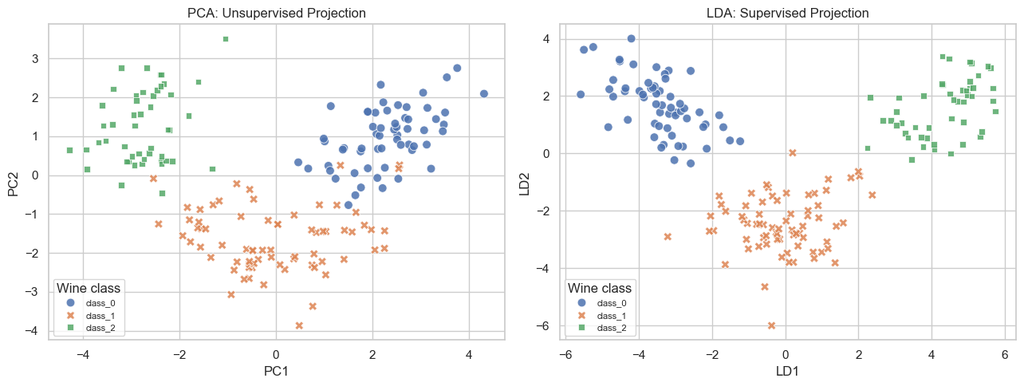

|  | Method | Uses class labels | 2D silhouette score |
| --- | --- | --- | --- |
| 0 | PCA | No | 0.5262 |
| 1 | LDA | Yes | 0.6632 |

```python
lda = LinearDiscriminantAnalysis(n_components=2)
X_lda = lda.fit_transform(X_wine_scaled, y_wine)
lda_df = pd.DataFrame(X_lda, columns=["LD1", "LD2"])
lda_df["Class"] = y_wine.map(dict(enumerate(wine.target_names)))

print("LDA explained discriminative variance ratio:", np.round(lda.explained_variance_ratio_, 4))

fig, axes = plt.subplots(1, 2, figsize=(13, 5))
sns.scatterplot(data=pca_df, x="PC1", y="PC2", hue="Class", style="Class", s=60, alpha=0.85, ax=axes[0])
axes[0].set_title("PCA: Unsupervised Projection")
sns.scatterplot(data=lda_df, x="LD1", y="LD2", hue="Class", style="Class", s=60, alpha=0.85, ax=axes[1])
axes[1].set_title("LDA: Supervised Projection")
for ax in axes:
    ax.legend(title="Wine class", fontsize=8)
plt.tight_layout()
plt.show()

separation = pd.DataFrame({
    "Method": ["PCA", "LDA"],
    "Uses class labels": ["No", "Yes"],
    "2D silhouette score": [silhouette_score(X_pca, y_wine), silhouette_score(X_lda, y_wine)],
})
display(separation.style.format({"2D silhouette score": "{:.4f}"}))
```

```python
print("Final observations:")
print(f"- PCA keeps {pca_2.explained_variance_ratio_.sum():.2%} of total variance in two components.")
print(f"- {min_components_95} principal components are required to retain at least 95% variance.")
print("- PCA preserves overall variation without using class labels.")
print("- LDA uses labels and gives clearer class separation in two dimensions.")
print("- PCA is suitable for general compression; LDA is useful when class separation is the goal.")
```

```
Final observations:
- PCA keeps 55.41% of total variance in two components.
- 10 principal components are required to retain at least 95% variance.
- PCA preserves overall variation without using class labels.
- LDA uses labels and gives clearer class separation in two dimensions.
- PCA is suitable for general compression; LDA is useful when class separation is the goal.
```